# Adding Instance Number

John Muschelli

2019-11-13

# 1 Description

This rundown shows how to add the instance number to a DICOM data set, using ImagePositionPatient to have the data to stack correctly.

# 2 Load up Packages

```r
library(dcm2niir)
library(dcmtk)
library(readr)
library(dplyr)
library(tidyr)
library(neurobase)
```

# 3 Data

The data is located at https://johnmuschelli.com/fixing_dicom_files/add_instance_number/data.zip

## 3.1 Download the data

```r
destfile = "data.zip"
if (!file.exists(destfile)) {
  url = "https://johnmuschelli.com/fixing_dicom_files/add_instance_number/data.zip"
  destfile = tempfile(fileext = ".zip")
  download.file(url, destfile)
}
```

My version of `dcm2niix` is the most up to date GitHub built from source:

```r
dcm2nii_version()
```

```
[1] "Chris Rorden's dcm2niiX version v1.0.20190410  (JP2:OpenJPEG) (JP-LS:CharLS) Clang8.1.0 (64-bit MacOS)"
```

If not, you can run `install_dcm2nii(from_source = TRUE, overwrite = TRUE)`.

Here we are unzipping the data to a temporary file so we can sandbox our changes to the data:

```r
exdir = tempfile()
dir.create(exdir)
unzip(destfile, exdir = exdir)
paths = list.files(pattern = ".dcm", path = exdir, full.names = TRUE)
```

Here is the header information:

```r
# showing the image position patient
hdr = read_dicom_header(path = exdir, recursive = TRUE)
```

```
/usr/local/bin/dcmdump -q --print-all --load-short --print-filename --recurse --scan-directories '/private/var/folders/1s/wrtqcpxn685_zk570bnx9_rr0000gr/T/RtmpI66EU2/file1689559d57428' --scan-pattern  *.dcm
```

```r
wide = wide_hdr(hdr)

sort(unique(hdr$name))
```

```
 [1] "BitsAllocated"                  "BitsStored"
 [3] "Columns"                        "FileMetaInformationGroupLength"
 [5] "FileMetaInformationVersion"     "HighBit"
 [7] "ImageOrientationPatient"        "ImagePositionPatient"
 [9] "ImplementationClassUID"         "ImplementationVersionName"
[11] "MediaStorageSOPClassUID"        "MediaStorageSOPInstanceUID"
[13] "Modality"                       "PatientID"
[15] "PhotometricInterpretation"      "PixelData"
[17] "PixelRepresentation"            "PixelSpacing"
[19] "RescaleIntercept"               "RescaleSlope"
[21] "Rows"                           "SamplesPerPixel"
[23] "SeriesInstanceUID"              "SOPInstanceUID"
[25] "StudyID"                        "StudyInstanceUID"
[27] "TransferSyntaxUID"              "WindowCenter"
[29] "WindowWidth"
```

## 3.2 Helper Functions

In order to parse some information on the DICOM header, we need some helper functions:

```r
library(readr)
parse_number_no_na = function(x) {
  x[ x %in% c("-", "-", "N/A")] = NA
  na_x = is.na(x)
  x = readr::parse_number(x, na = "")
  bad = is.na(x) & !na_x
  stopifnot(!any(bad))
  x
}

sub_bracket = function(x) {
  x = sub("^\\[", "", x)
  x = sub("\\]$", "", x)
  x = trimws(x)
}
```

## 3.3 DICOM Headers are missing

```r
# no gantry tilt DICOM header!
any(grepl("ilt", tolower(hdr$name)))
```

```
[1] FALSE
```

```r
any(grepl("instancenum", tolower(hdr$name)))
```

```
[1] FALSE
```

```r
wide = wide %>%
  mutate(ipp = sub_bracket(gsub("\\\\", ",", ImagePositionPatient))) %>%
  tidyr::separate(ipp, into = c("x", "y", "z"), remove = FALSE, sep = ",") %>%
  mutate_at(vars(x, y, z), parse_number_no_na)

# order by z
wide = wide %>%
  select(file, x, y, z, ipp) %>%
  arrange(z)
```

Showing the image position patients (ordered for instance number later)

```r
wide %>%
  mutate(file = basename(file)) %>%
  select(file, x, y, z) %>%
  as.data.frame
```

```
               file         x            y         z
1  ID_12a0d6d34.dcm -82.00099 -39.17097000  95.26095
2  ID_12e3b6923.dcm -82.00099 -37.66793000 100.02969
3  ID_6b15a7649.dcm -82.00099 -36.16490000 104.79843
4  ID_7c08b7fb7.dcm -82.00099 -34.66185762 109.56717
5  ID_6cb797177.dcm -82.00099 -33.15882000 114.33591
6  ID_bb2a4a01c.dcm -82.00099 -31.65578000 119.10465
7  ID_6dcedd2e1.dcm -82.00099 -30.15274000 123.87339
8  ID_b494c2115.dcm -82.00099 -28.64971000 128.64213
9  ID_ae7b11865.dcm -82.00099 -27.14667000 133.41087
10 ID_21053fe7e.dcm -82.00099 -25.64363056 138.17961
11 ID_f4891876d.dcm -82.00099 -24.14059000 142.94835
12 ID_18aac96c0.dcm -82.00099 -22.63755000 147.71709
13 ID_8a35660d5.dcm -82.00099 -21.13452000 152.48583
14 ID_d4ea87a35.dcm -82.00099 -19.63148000 157.25457
```

[output cut: 17 more lines]

Here is the output of `dcm2niix` on the original data

```r
d_res = dcm2nii(
  basedir = exdir,
  opts = " -v y ")
```

```
#Copying Files
```

```
# Converting to nii
```

```
'/Library/Frameworks/R.framework/Versions/3.6/Resources/library/dcm2niir/dcm2niix'  -v y  '/var/folders/1s/wrtqcpxn685_zk570bnx9_rr0000gr/T/RtmpI66EU2/file1689520485036'
```

```r
d_res
```

```
$result
[1] 1

$nii_before
character(0)

$nii_after
[1] "/var/folders/1s/wrtqcpxn685_zk570bnx9_rr0000gr/T/RtmpI66EU2/file1689520485036/_0_3760890702.nii.gz"

$json_after
[1] "/var/folders/1s/wrtqcpxn685_zk570bnx9_rr0000gr/T/RtmpI66EU2/file1689520485036/_0_3760890702.json"

$json_before
character(0)

$cmd
[1] "'/Library/Frameworks/R.framework/Versions/3.6/Resources/library/dcm2niir/dcm2niix'  -v y  '/var/folders/1s/wrtqcpxn685_zk570bnx9_rr0000gr/T/RtmpI66EU2/file1689520485036'"
```

```r
img = readnii(d_res$nii_after)
dim(img)
```

```
[1] 404 430  31
```

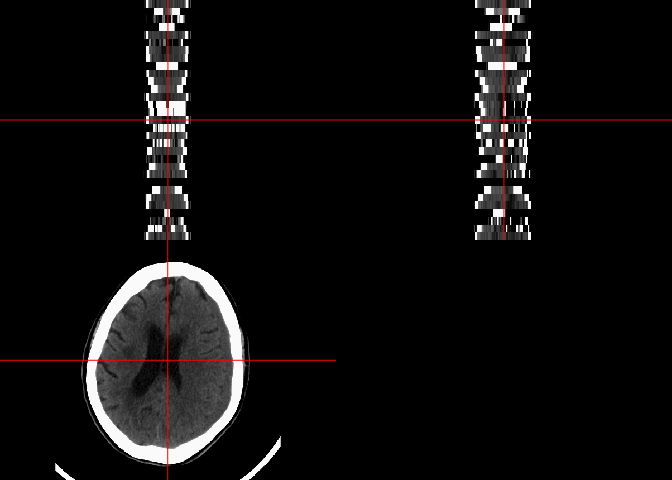

```r
ortho2(window_img(img))
```

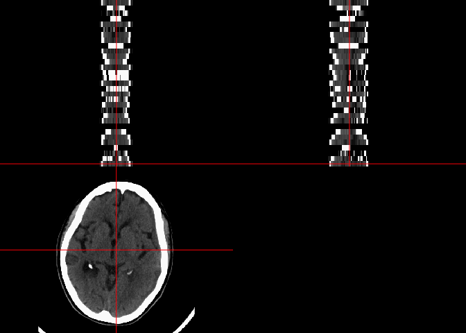

```r
ortho2(window_img(img), xyz = c(202, 215, 1))
```

# 4 Fixing the Instance Number

## 4.1 Copy the data

Here we are copying the data to a different folder to make instance number

```r
tmpdir = tempfile()
dir.create(tmpdir)
file.copy(paths, tmpdir)
```

```
 [1] TRUE TRUE TRUE TRUE TRUE TRUE TRUE TRUE TRUE TRUE TRUE TRUE TRUE TRUE
[15] TRUE TRUE TRUE TRUE TRUE TRUE TRUE TRUE TRUE TRUE TRUE TRUE TRUE TRUE
[29] TRUE TRUE TRUE
```

## 4.2 Modifying the Instance Number

Here we are making the instance number spatial on z, modifying the instance number using the tag `(0020,0013)`:

```r
tmp_paths = file.path(tmpdir, basename(wide$file))
ind = seq_along(tmp_paths)
add_instance = function(file, index) {
  dcmtk::dcmodify(
    file = file,
    frontopts = paste0('-i "(0020,0013)=', index, '"')
  )
  hdr = read_dicom_header(file)
  new_inst = as.numeric(sub_bracket(hdr$value[hdr$name == "InstanceNumber"]))
  stopifnot(new_inst == index)
  print(new_inst)
  bakfile = paste0(file, ".bak")
  if (file.exists(bakfile)) {
    file.remove(bakfile)
  }
}
res = mapply(add_instance, tmp_paths, ind)
```

```
/usr/local/bin/dcmodify -i "(0020,0013)=1"  /var/folders/1s/wrtqcpxn685_zk570bnx9_rr0000gr/T//RtmpI66EU2/file16895222ed4e9/ID_12a0d6d34.dcm
```

```
/usr/local/bin/dcmdump -q --print-all --load-short --print-filename  /var/folders/1s/wrtqcpxn685_zk570bnx9_rr0000gr/T//RtmpI66EU2/file16895222ed4e9/ID_12a0d6d34.dcm
```

```
[1] 1
```

```
/usr/local/bin/dcmodify -i "(0020,0013)=2"  /var/folders/1s/wrtqcpxn685_zk570bnx9_rr0000gr/T//RtmpI66EU2/file16895222ed4e9/ID_12e3b6923.dcm
```

```
/usr/local/bin/dcmdump -q --print-all --load-short --print-filename  /var/folders/1s/wrtqcpxn685_zk570bnx9_rr0000gr/T//RtmpI66EU2/file16895222ed4e9/ID_12e3b6923.dcm
```

```
[1] 2
```

```
/usr/local/bin/dcmodify -i "(0020,0013)=3"  /var/folders/1s/wrtqcpxn685_zk570bnx9_rr0000gr/T//RtmpI66EU2/file16895222ed4e9/ID_6b15a7649.dcm
```

```
/usr/local/bin/dcmdump -q --print-all --load-short --print-filename  /var/folders/1s/wrtqcpxn685_zk570bnx9_rr0000gr/T//RtmpI66EU2/file16895222ed4e9/ID_6b15a7649.dcm
```

```
[1] 3
```

```
/usr/local/bin/dcmodify -i "(0020,0013)=4"  /var/folders/1s/wrtqcpxn685_zk570bnx9_rr0000gr/T//RtmpI66EU2/file16895222ed4e9/ID_7c08b7fb7.dcm
```

```
/usr/local/bin/dcmdump -q --print-all --load-short --print-filename  /var/folders/1s/wrtqcpxn685_zk570bnx9_rr0000gr/T//RtmpI66EU2/file16895222ed4e9/ID_7c08b7fb7.dcm
```

```
[1] 4
```

```
/usr/local/bin/dcmodify -i "(0020,0013)=5"  /var/folders/1s/wrtqcpxn685_zk570bnx9_rr0000gr/T//RtmpI66EU2/file16895222ed4e9/ID_6cb797177.dcm
```

```
/usr/local/bin/dcmdump -q --print-all --load-short --print-filename  /var/folders/1s/wrtqcpxn685_zk570bnx9_rr0000gr/T//RtmpI66EU2/file16895222ed4e9/ID_6cb797177.dcm
```

```
[1] 5
```

```
/usr/local/bin/dcmodify -i "(0020,0013)=6"  /var/folders/1s/wrtqcpxn685_zk570bnx9_rr0000gr/T//RtmpI66EU2/file16895222ed4e9/ID_bb2a4a01c.dcm
```

```
/usr/local/bin/dcmdump -q --print-all --load-short --print-filename  /var/folders/1s/wrtqcpxn685_zk570bnx9_rr0000gr/T//RtmpI66EU2/file16895222ed4e9/ID_bb2a4a01c.dcm
```

```
[1] 6
```

```
/usr/local/bin/dcmodify -i "(0020,0013)=7"  /var/folders/1s/wrtqcpxn685_zk570bnx9_rr0000gr/T//RtmpI66EU2/file16895222ed4e9/ID_6dcedd2e1.dcm
```

```
/usr/local/bin/dcmdump -q --print-all --load-short --print-filename  /var/folders/1s/wrtqcpxn685_zk570bnx9_rr0000gr/T//RtmpI66EU2/file16895222ed4e9/ID_6dcedd2e1.dcm
```

```
[1] 7
```

```
/usr/local/bin/dcmodify -i "(0020,0013)=8"  /var/folders/1s/wrtqcpxn685_zk570bnx9_rr0000gr/T//RtmpI66EU2/file16895222ed4e9/ID_b494c2115.dcm
```

```
/usr/local/bin/dcmdump -q --print-all --load-short --print-filename  /var/folders/1s/wrtqcpxn685_zk570bnx9_rr0000gr/T//RtmpI66EU2/file16895222ed4e9/ID_b494c2115.dcm
```

```
[1] 8
```

```
/usr/local/bin/dcmodify -i "(0020,0013)=9"  /var/folders/1s/wrtqcpxn685_zk570bnx9_rr0000gr/T//RtmpI66EU2/file16895222ed4e9/ID_ae7b11865.dcm
```

```
/usr/local/bin/dcmdump -q --print-all --load-short --print-filename  /var/folders/1s/wrtqcpxn685_zk570bnx9_rr0000gr/T//RtmpI66EU2/file16895222ed4e9/ID_ae7b11865.dcm
```

```
[1] 9
```

```
/usr/local/bin/dcmodify -i "(0020,0013)=10"  /var/folders/1s/wrtqcpxn685_zk570bnx9_rr0000gr/T//RtmpI66EU2/file16895222ed4e9/ID_21053fe7e.dcm
```

```
/usr/local/bin/dcmdump -q --print-all --load-short --print-filename  /var/folders/1s/wrtqcpxn685_zk570bnx9_rr0000gr/T//RtmpI66EU2/file16895222ed4e9/ID_21053fe7e.dcm
```

```
[1] 10
```

```
/usr/local/bin/dcmodify -i "(0020,0013)=11"  /var/folders/1s/wrtqcpxn685_zk570bnx9_rr0000gr/T//RtmpI66EU2/file16895222ed4e9/ID_f4891876d.dcm
```

```
/usr/local/bin/dcmdump -q --print-all --load-short --print-filename  /var/folders/1s/wrtqcpxn685_zk570bnx9_rr0000gr/T//RtmpI66EU2/file16895222ed4e9/ID_f4891876d.dcm
```

```
[1] 11
```

```
/usr/local/bin/dcmodify -i "(0020,0013)=12"  /var/folders/1s/wrtqcpxn685_zk570bnx9_rr0000gr/T//RtmpI66EU2/file16895222ed4e9/ID_18aac96c0.dcm
```

```
/usr/local/bin/dcmdump -q --print-all --load-short --print-filename  /var/folders/1s/wrtqcpxn685_zk570bnx9_rr0000gr/T//RtmpI66EU2/file16895222ed4e9/ID_18aac96c0.dcm
```

```
[1] 12
```

```
/usr/local/bin/dcmodify -i "(0020,0013)=13"  /var/folders/1s/wrtqcpxn685_zk570bnx9_rr0000gr/T//RtmpI66EU2/file16895222ed4e9/ID_8a35660d5.dcm
```

```
/usr/local/bin/dcmdump -q --print-all --load-short --print-filename  /var/folders/1s/wrtqcpxn685_zk570bnx9_rr0000gr/T//RtmpI66EU2/file16895222ed4e9/ID_8a35660d5.dcm
```

```
[1] 13
```

```
/usr/local/bin/dcmodify -i "(0020,0013)=14"  /var/folders/1s/wrtqcpxn685_zk570bnx9_rr0000gr/T//RtmpI66EU2/file16895222ed4e9/ID_d4ea87a35.dcm
```

```
/usr/local/bin/dcmdump -q --print-all --load-short --print-filename  /var/folders/1s/wrtqcpxn685_zk570bnx9_rr0000gr/T//RtmpI66EU2/file16895222ed4e9/ID_d4ea87a35.dcm
```

```
[1] 14
```

```
/usr/local/bin/dcmodify -i "(0020,0013)=15"  /var/folders/1s/wrtqcpxn685_zk570bnx9_rr0000gr/T//RtmpI66EU2/file16895222ed4e9/ID_0b0e59911.dcm
```

```
/usr/local/bin/dcmdump -q --print-all --load-short --print-filename  /var/folders/1s/wrtqcpxn685_zk570bnx9_rr0000gr/T//RtmpI66EU2/file16895222ed4e9/ID_0b0e59911.dcm
```

```
[1] 15
```

```
/usr/local/bin/dcmodify -i "(0020,0013)=16"  /var/folders/1s/wrtqcpxn685_zk570bnx9_rr0000gr/T//RtmpI66EU2/file16895222ed4e9/ID_97e5a203e.dcm
```

```
/usr/local/bin/dcmdump -q --print-all --load-short --print-filename  /var/folders/1s/wrtqcpxn685_zk570bnx9_rr0000gr/T//RtmpI66EU2/file16895222ed4e9/ID_97e5a203e.dcm
```

```
[1] 16
```

```
/usr/local/bin/dcmodify -i "(0020,0013)=17"  /var/folders/1s/wrtqcpxn685_zk570bnx9_rr0000gr/T//RtmpI66EU2/file16895222ed4e9/ID_ac39010dc.dcm
```

```
/usr/local/bin/dcmdump -q --print-all --load-short --print-filename  /var/folders/1s/wrtqcpxn685_zk570bnx9_rr0000gr/T//RtmpI66EU2/file16895222ed4e9/ID_ac39010dc.dcm
```

```
[1] 17
```

```
/usr/local/bin/dcmodify -i "(0020,0013)=18"  /var/folders/1s/wrtqcpxn685_zk570bnx9_rr0000gr/T//RtmpI66EU2/file16895222ed4e9/ID_4f0317d23.dcm
```

```
/usr/local/bin/dcmdump -q --print-all --load-short --print-filename  /var/folders/1s/wrtqcpxn685_zk570bnx9_rr0000gr/T//RtmpI66EU2/file16895222ed4e9/ID_4f0317d23.dcm
```

```
[1] 18
```

```
/usr/local/bin/dcmodify -i "(0020,0013)=19"  /var/folders/1s/wrtqcpxn685_zk570bnx9_rr0000gr/T//RtmpI66EU2/file16895222ed4e9/ID_362423b57.dcm
```

```
/usr/local/bin/dcmdump -q --print-all --load-short --print-filename  /var/folders/1s/wrtqcpxn685_zk570bnx9_rr0000gr/T//RtmpI66EU2/file16895222ed4e9/ID_362423b57.dcm
```

```
[1] 19
```

```
/usr/local/bin/dcmodify -i "(0020,0013)=20"  /var/folders/1s/wrtqcpxn685_zk570bnx9_rr0000gr/T//RtmpI66EU2/file16895222ed4e9/ID_dd3b5bf4e.dcm
```

```
/usr/local/bin/dcmdump -q --print-all --load-short --print-filename  /var/folders/1s/wrtqcpxn685_zk570bnx9_rr0000gr/T//RtmpI66EU2/file16895222ed4e9/ID_dd3b5bf4e.dcm
```

```
[1] 20
```

```
/usr/local/bin/dcmodify -i "(0020,0013)=21"  /var/folders/1s/wrtqcpxn685_zk570bnx9_rr0000gr/T//RtmpI66EU2/file16895222ed4e9/ID_8f5d4b696.dcm
```

```
/usr/local/bin/dcmdump -q --print-all --load-short --print-filename  /var/folders/1s/wrtqcpxn685_zk570bnx9_rr0000gr/T//RtmpI66EU2/file16895222ed4e9/ID_8f5d4b696.dcm
```

```
[1] 21
```

```
/usr/local/bin/dcmodify -i "(0020,0013)=22"  /var/folders/1s/wrtqcpxn685_zk570bnx9_rr0000gr/T//RtmpI66EU2/file16895222ed4e9/ID_66accd2e4.dcm
```

```
/usr/local/bin/dcmdump -q --print-all --load-short --print-filename  /var/folders/1s/wrtqcpxn685_zk570bnx9_rr0000gr/T//RtmpI66EU2/file16895222ed4e9/ID_66accd2e4.dcm
```

```
[1] 22
```

```
/usr/local/bin/dcmodify -i "(0020,0013)=23"  /var/folders/1s/wrtqcpxn685_zk570bnx9_rr0000gr/T//RtmpI66EU2/file16895222ed4e9/ID_17103c79e.dcm
```

```
/usr/local/bin/dcmdump -q --print-all --load-short --print-filename  /var/folders/1s/wrtqcpxn685_zk570bnx9_rr0000gr/T//RtmpI66EU2/file16895222ed4e9/ID_17103c79e.dcm
```

```
[1] 23
```

```
/usr/local/bin/dcmodify -i "(0020,0013)=24"  /var/folders/1s/wrtqcpxn685_zk570bnx9_rr0000gr/T//RtmpI66EU2/file16895222ed4e9/ID_9a3bba619.dcm
```

```
/usr/local/bin/dcmdump -q --print-all --load-short --print-filename  /var/folders/1s/wrtqcpxn685_zk570bnx9_rr0000gr/T//RtmpI66EU2/file16895222ed4e9/ID_9a3bba619.dcm
```

```
[1] 24
```

```
/usr/local/bin/dcmodify -i "(0020,0013)=25"  /var/folders/1s/wrtqcpxn685_zk570bnx9_rr0000gr/T//RtmpI66EU2/file16895222ed4e9/ID_8d0ca7742.dcm
```

```
/usr/local/bin/dcmdump -q --print-all --load-short --print-filename  /var/folders/1s/wrtqcpxn685_zk570bnx9_rr0000gr/T//RtmpI66EU2/file16895222ed4e9/ID_8d0ca7742.dcm
```

```
[1] 25
```

```
/usr/local/bin/dcmodify -i "(0020,0013)=26"  /var/folders/1s/wrtqcpxn685_zk570bnx9_rr0000gr/T//RtmpI66EU2/file16895222ed4e9/ID_c4575f13b.dcm
```

```
/usr/local/bin/dcmdump -q --print-all --load-short --print-filename  /var/folders/1s/wrtqcpxn685_zk570bnx9_rr0000gr/T//RtmpI66EU2/file16895222ed4e9/ID_c4575f13b.dcm
```

```
[1] 26
```

```
/usr/local/bin/dcmodify -i "(0020,0013)=27"  /var/folders/1s/wrtqcpxn685_zk570bnx9_rr0000gr/T//RtmpI66EU2/file16895222ed4e9/ID_3cb1b59bc.dcm
```

```
/usr/local/bin/dcmdump -q --print-all --load-short --print-filename  /var/folders/1s/wrtqcpxn685_zk570bnx9_rr0000gr/T//RtmpI66EU2/file16895222ed4e9/ID_3cb1b59bc.dcm
```

```
[1] 27
```

```
/usr/local/bin/dcmodify -i "(0020,0013)=28"  /var/folders/1s/wrtqcpxn685_zk570bnx9_rr0000gr/T//RtmpI66EU2/file16895222ed4e9/ID_c35d5c858.dcm
```

```
/usr/local/bin/dcmdump -q --print-all --load-short --print-filename  /var/folders/1s/wrtqcpxn685_zk570bnx9_rr0000gr/T//RtmpI66EU2/file16895222ed4e9/ID_c35d5c858.dcm
```

```
[1] 28
```

```
/usr/local/bin/dcmodify -i "(0020,0013)=29"  /var/folders/1s/wrtqcpxn685_zk570bnx9_rr0000gr/T//RtmpI66EU2/file16895222ed4e9/ID_317330708.dcm
```

```
/usr/local/bin/dcmdump -q --print-all --load-short --print-filename  /var/folders/1s/wrtqcpxn685_zk570bnx9_rr0000gr/T//RtmpI66EU2/file16895222ed4e9/ID_317330708.dcm
```

```
[1] 29
```

```
/usr/local/bin/dcmodify -i "(0020,0013)=30"  /var/folders/1s/wrtqcpxn685_zk570bnx9_rr0000gr/T//RtmpI66EU2/file16895222ed4e9/ID_8144c7120.dcm
```

```
/usr/local/bin/dcmdump -q --print-all --load-short --print-filename  /var/folders/1s/wrtqcpxn685_zk570bnx9_rr0000gr/T//RtmpI66EU2/file16895222ed4e9/ID_8144c7120.dcm
```

```
[1] 30
```

```
/usr/local/bin/dcmodify -i "(0020,0013)=31"  /var/folders/1s/wrtqcpxn685_zk570bnx9_rr0000gr/T//RtmpI66EU2/file16895222ed4e9/ID_d7777de78.dcm
```

```
/usr/local/bin/dcmdump -q --print-all --load-short --print-filename  /var/folders/1s/wrtqcpxn685_zk570bnx9_rr0000gr/T//RtmpI66EU2/file16895222ed4e9/ID_d7777de78.dcm
```

```
[1] 31
```

Checking the instance number is correct:

```r
tmp_hdr = lapply(tmp_paths, read_dicom_header)
```

```
/usr/local/bin/dcmdump -q --print-all --load-short --print-filename  /var/folders/1s/wrtqcpxn685_zk570bnx9_rr0000gr/T//RtmpI66EU2/file16895222ed4e9/ID_12a0d6d34.dcm
```

```
/usr/local/bin/dcmdump -q --print-all --load-short --print-filename  /var/folders/1s/wrtqcpxn685_zk570bnx9_rr0000gr/T//RtmpI66EU2/file16895222ed4e9/ID_12e3b6923.dcm
```

```
/usr/local/bin/dcmdump -q --print-all --load-short --print-filename  /var/folders/1s/wrtqcpxn685_zk570bnx9_rr0000gr/T//RtmpI66EU2/file16895222ed4e9/ID_6b15a7649.dcm
```

```
/usr/local/bin/dcmdump -q --print-all --load-short --print-filename  /var/folders/1s/wrtqcpxn685_zk570bnx9_rr0000gr/T//RtmpI66EU2/file16895222ed4e9/ID_7c08b7fb7.dcm
```

```
/usr/local/bin/dcmdump -q --print-all --load-short --print-filename  /var/folders/1s/wrtqcpxn685_zk570bnx9_rr0000gr/T//RtmpI66EU2/file16895222ed4e9/ID_6cb797177.dcm
```

```
/usr/local/bin/dcmdump -q --print-all --load-short --print-filename  /var/folders/1s/wrtqcpxn685_zk570bnx9_rr0000gr/T//RtmpI66EU2/file16895222ed4e9/ID_bb2a4a01c.dcm
```

```
/usr/local/bin/dcmdump -q --print-all --load-short --print-filename  /var/folders/1s/wrtqcpxn685_zk570bnx9_rr0000gr/T//RtmpI66EU2/file16895222ed4e9/ID_6dcedd2e1.dcm
```

```
/usr/local/bin/dcmdump -q --print-all --load-short --print-filename  /var/folders/1s/wrtqcpxn685_zk570bnx9_rr0000gr/T//RtmpI66EU2/file16895222ed4e9/ID_b494c2115.dcm
```

```
/usr/local/bin/dcmdump -q --print-all --load-short --print-filename  /var/folders/1s/wrtqcpxn685_zk570bnx9_rr0000gr/T//RtmpI66EU2/file16895222ed4e9/ID_ae7b11865.dcm
```

```
/usr/local/bin/dcmdump -q --print-all --load-short --print-filename  /var/folders/1s/wrtqcpxn685_zk570bnx9_rr0000gr/T//RtmpI66EU2/file16895222ed4e9/ID_21053fe7e.dcm
```

```
/usr/local/bin/dcmdump -q --print-all --load-short --print-filename  /var/folders/1s/wrtqcpxn685_zk570bnx9_rr0000gr/T//RtmpI66EU2/file16895222ed4e9/ID_f4891876d.dcm
```

```
/usr/local/bin/dcmdump -q --print-all --load-short --print-filename  /var/folders/1s/wrtqcpxn685_zk570bnx9_rr0000gr/T//RtmpI66EU2/file16895222ed4e9/ID_18aac96c0.dcm
```

```
/usr/local/bin/dcmdump -q --print-all --load-short --print-filename  /var/folders/1s/wrtqcpxn685_zk570bnx9_rr0000gr/T//RtmpI66EU2/file16895222ed4e9/ID_8a35660d5.dcm
```

```
/usr/local/bin/dcmdump -q --print-all --load-short --print-filename  /var/folders/1s/wrtqcpxn685_zk570bnx9_rr0000gr/T//RtmpI66EU2/file16895222ed4e9/ID_d4ea87a35.dcm
```

```
/usr/local/bin/dcmdump -q --print-all --load-short --print-filename  /var/folders/1s/wrtqcpxn685_zk570bnx9_rr0000gr/T//RtmpI66EU2/file16895222ed4e9/ID_0b0e59911.dcm
```

```
/usr/local/bin/dcmdump -q --print-all --load-short --print-filename  /var/folders/1s/wrtqcpxn685_zk570bnx9_rr0000gr/T//RtmpI66EU2/file16895222ed4e9/ID_97e5a203e.dcm
```

```
/usr/local/bin/dcmdump -q --print-all --load-short --print-filename  /var/folders/1s/wrtqcpxn685_zk570bnx9_rr0000gr/T//RtmpI66EU2/file16895222ed4e9/ID_ac39010dc.dcm
```

```
/usr/local/bin/dcmdump -q --print-all --load-short --print-filename  /var/folders/1s/wrtqcpxn685_zk570bnx9_rr0000gr/T//RtmpI66EU2/file16895222ed4e9/ID_4f0317d23.dcm
```

```
/usr/local/bin/dcmdump -q --print-all --load-short --print-filename  /var/folders/1s/wrtqcpxn685_zk570bnx9_rr0000gr/T//RtmpI66EU2/file16895222ed4e9/ID_362423b57.dcm
```

```
/usr/local/bin/dcmdump -q --print-all --load-short --print-filename  /var/folders/1s/wrtqcpxn685_zk570bnx9_rr0000gr/T//RtmpI66EU2/file16895222ed4e9/ID_dd3b5bf4e.dcm
```

```
/usr/local/bin/dcmdump -q --print-all --load-short --print-filename  /var/folders/1s/wrtqcpxn685_zk570bnx9_rr0000gr/T//RtmpI66EU2/file16895222ed4e9/ID_8f5d4b696.dcm
```

```
/usr/local/bin/dcmdump -q --print-all --load-short --print-filename  /var/folders/1s/wrtqcpxn685_zk570bnx9_rr0000gr/T//RtmpI66EU2/file16895222ed4e9/ID_66accd2e4.dcm
```

```
/usr/local/bin/dcmdump -q --print-all --load-short --print-filename  /var/folders/1s/wrtqcpxn685_zk570bnx9_rr0000gr/T//RtmpI66EU2/file16895222ed4e9/ID_17103c79e.dcm
```

```
/usr/local/bin/dcmdump -q --print-all --load-short --print-filename  /var/folders/1s/wrtqcpxn685_zk570bnx9_rr0000gr/T//RtmpI66EU2/file16895222ed4e9/ID_9a3bba619.dcm
```

```
/usr/local/bin/dcmdump -q --print-all --load-short --print-filename  /var/folders/1s/wrtqcpxn685_zk570bnx9_rr0000gr/T//RtmpI66EU2/file16895222ed4e9/ID_8d0ca7742.dcm
```

```
/usr/local/bin/dcmdump -q --print-all --load-short --print-filename  /var/folders/1s/wrtqcpxn685_zk570bnx9_rr0000gr/T//RtmpI66EU2/file16895222ed4e9/ID_c4575f13b.dcm
```

```
/usr/local/bin/dcmdump -q --print-all --load-short --print-filename  /var/folders/1s/wrtqcpxn685_zk570bnx9_rr0000gr/T//RtmpI66EU2/file16895222ed4e9/ID_3cb1b59bc.dcm
```

```
/usr/local/bin/dcmdump -q --print-all --load-short --print-filename  /var/folders/1s/wrtqcpxn685_zk570bnx9_rr0000gr/T//RtmpI66EU2/file16895222ed4e9/ID_c35d5c858.dcm
```

```
/usr/local/bin/dcmdump -q --print-all --load-short --print-filename  /var/folders/1s/wrtqcpxn685_zk570bnx9_rr0000gr/T//RtmpI66EU2/file16895222ed4e9/ID_317330708.dcm
```

```
/usr/local/bin/dcmdump -q --print-all --load-short --print-filename  /var/folders/1s/wrtqcpxn685_zk570bnx9_rr0000gr/T//RtmpI66EU2/file16895222ed4e9/ID_8144c7120.dcm
```

```
/usr/local/bin/dcmdump -q --print-all --load-short --print-filename  /var/folders/1s/wrtqcpxn685_zk570bnx9_rr0000gr/T//RtmpI66EU2/file16895222ed4e9/ID_d7777de78.dcm
```

```r
tmp_hdr = bind_rows(tmp_hdr)
# arranging because reshaping can cause reordering of files
tmp_hdr = tmp_hdr %>%
  mutate(file = factor(tmp_hdr$file, levels = tmp_paths)) %>%
  arrange(file)
tmp_wide = wide_hdr(tmp_hdr)
tmp_wide$InstanceNumber
```

```
 [1] "[1]"  "[2]"  "[3]"  "[4]"  "[5]"  "[6]"  "[7]"  "[8]"  "[9]"  "[10]"
[11] "[11]" "[12]" "[13]" "[14]" "[15]" "[16]" "[17]" "[18]" "[19]" "[20]"
[21] "[21]" "[22]" "[23]" "[24]" "[25]" "[26]" "[27]" "[28]" "[29]" "[30]"
[31] "[31]"
```

Checking the output with filled in instance number

```r
inst_res = dcm2nii(
  basedir = tmpdir,
  # files = tmp_paths,
  opts = " -v y ")
```

```
#Copying Files
```

```
# Converting to nii
```

```
'/Library/Frameworks/R.framework/Versions/3.6/Resources/library/dcm2niir/dcm2niix'  -v y  '/var/folders/1s/wrtqcpxn685_zk570bnx9_rr0000gr/T/RtmpI66EU2/file1689530146c2c'
```

```r
inst_res
```

```
$result
[1] 0

$nii_before
character(0)

$nii_after
[1] "/var/folders/1s/wrtqcpxn685_zk570bnx9_rr0000gr/T/RtmpI66EU2/file1689530146c2c/_0_3760890702.nii.gz"

$json_after
[1] "/var/folders/1s/wrtqcpxn685_zk570bnx9_rr0000gr/T/RtmpI66EU2/file1689530146c2c/_0_3760890702.json"

$json_before
character(0)

$cmd
[1] "'/Library/Frameworks/R.framework/Versions/3.6/Resources/library/dcm2niir/dcm2niix'  -v y  '/var/folders/1s/wrtqcpxn685_zk570bnx9_rr0000gr/T/RtmpI66EU2/file1689530146c2c'"
```

```r
inst_img = readnii(inst_res$nii_after)
dim(inst_img)
```

```
[1] 404 430  31
```

## 4.3 Correct Output

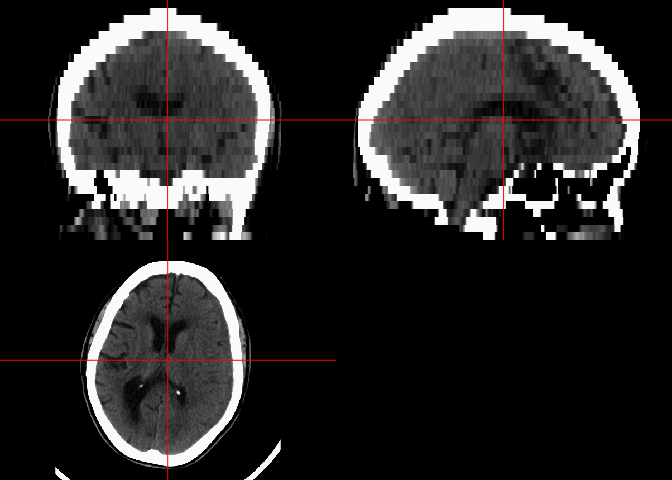

```r
ortho2(window_img(inst_img))
```

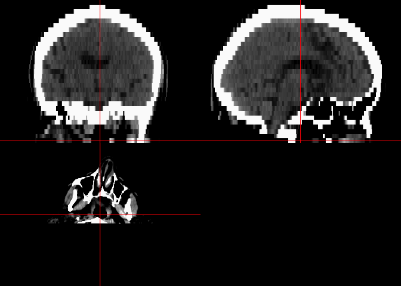

```r
ortho2(window_img(inst_img), xyz = c(202, 215, 1))
```